# Modeling and prediction for movies

## Setup

### Load packages

```r
library(ggplot2)
library(dplyr)
library(statsr)
```

### Load data

Make sure your data and R Markdown files are in the same directory. When loaded your data file will be called `movies`. Delete this note when before you submit your work.

```r
load("movies.Rdata")
```

## Part 1: Data

The Movies Dataset is a a random sample of movies with information from Rotten Tomatoes and IMDB designed to learn attributes responsible for making a movie popular. Movies data set is an observational study where the independent variables are not under the control of the researcher. The data set is a random sample of 651 movies from all the movies available in the imdb and Rotten tomatoes database.

##### CAUSALITY:

Association does not mean causation. Movies dataset is an observational study dataset to measure something new about movies. Establishing causation by ruling out the possibility of any lurking variable, or by assuming that individuals differ only with respect to the values of the explanatory variable is difficult. Due to the lurking variables, it is not preferable to establish causation in an observational study.

## Part 2: Research question

I have thought of 2 research questions from the Movies dataset.

Is there any association between a movie being boxoffice hit (top200_box) and variables title_type,genre,runtime,mpaa_rating,imdb ratings,rotten tomatoes score and oscar nominations?

Is there any relation between a movie admired by audience(audience score) and variables title_type,genre,runtime,mpaa_rating,imdb ratings,rotten tomatoes score,critics ratings and oscar nominations? * * *

## Part 3: Exploratory data analysis

Plotting Relation between variables in the movies dataset.

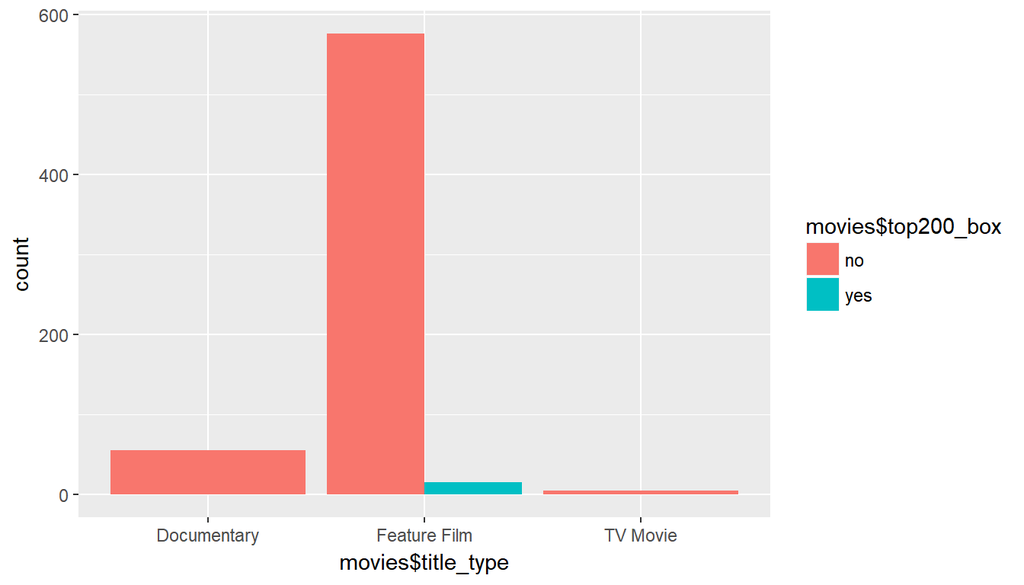

```r
 df <- data.frame(movies$title_type,movies$top200_box)
ggplot(df, aes(movies$title_type, ..count..)) + geom_bar(aes(fill = movies$top200_box), position = "dodge")
```

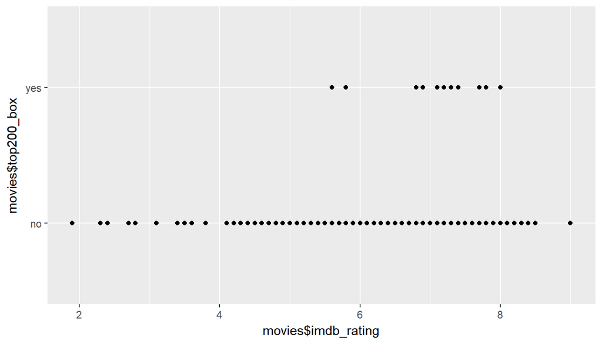

```r
ggplot(movies,aes(movies$imdb_rating,movies$top200_box))+geom_point()
```

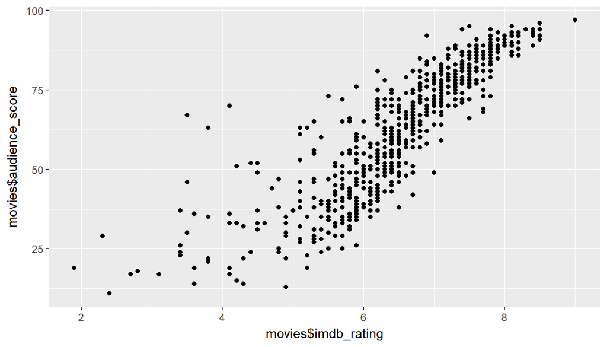

```r
 ggplot(movies,aes(movies$imdb_rating,movies$audience_score))+geom_point()
```

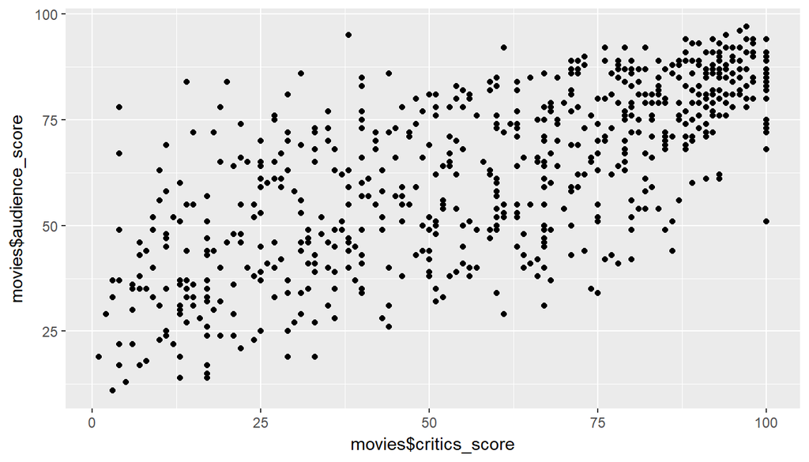

```r
 ggplot(movies,aes(movies$critics_score,movies$audience_score))+geom_point()
```

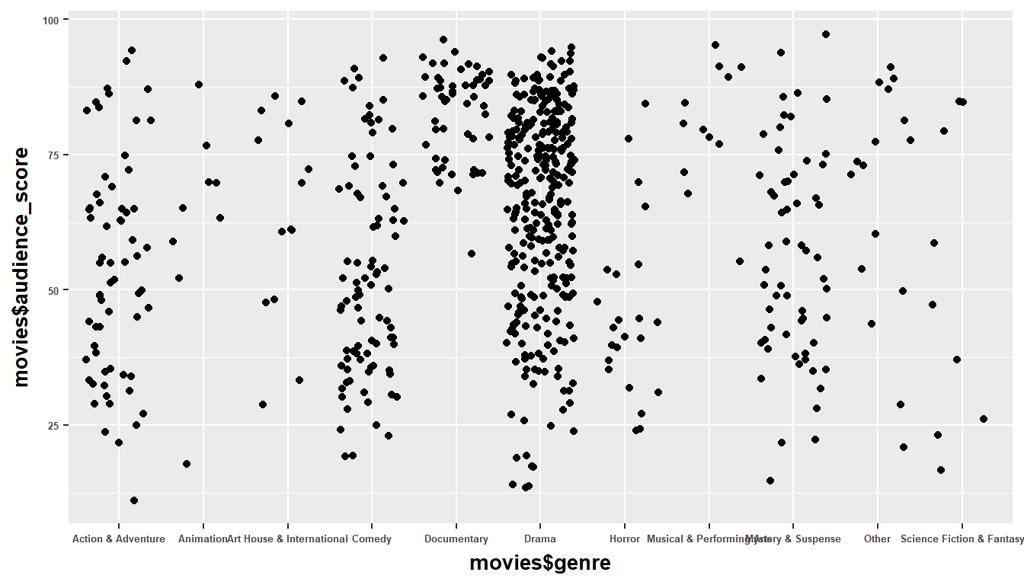

```r
 ggplot(movies,aes(movies$genre,movies$audience_score))+geom_jitter()+theme(axis.text=element_text(size=5,face="bold"),axis.title=element_text(size=10,face="bold"))
```

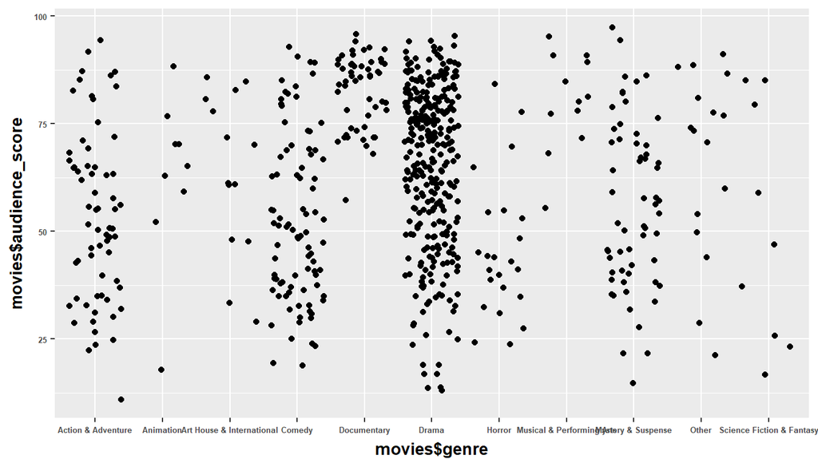

```r
 ggplot(movies,aes(movies$genre,movies$audience_score))+geom_jitter()+theme(axis.text=element_text(size=5,face="bold"),axis.title=element_text(size=10,face="bold"))
```

Cleaning The Movies Dataset to check and omit all N/A rows which might cause a faulty prediction.

```r
count=0
count=ifelse(is.na(movies)==TRUE,count+1,count)
sum(count)
```

```
## [1] 81
```

```r
movies_new<-na.omit(movies)
count=0
count=ifelse(is.na(movies_new)==TRUE,count+1,count)
sum(count)
```

```
## [1] 0
```

## Part 4: Modeling

As per the first reseasrch question ,I have used backward selection method to eliminate the highest p-value and retain the best possible Adjusted R-Squared. But as the top box office is a categorical vairable with 2 values “yes” and “no”,Decision trees is the best possible Data mining Model But to build a linear regression model we have change it to numeric with as.numeric function in R which converts Yes =2 and No=1 (For Simplicity I subtracted with 1)

```r
score<-as.numeric(movies_new$top200_box)-1
m_full <- lm(score ~  genre + runtime + mpaa_rating +as.factor(thtr_rel_month) + critics_rating + audience_rating , data = movies_new)
summary(m_full)
```

```
##
## Call:
## lm(formula = score ~ genre + runtime + mpaa_rating + as.factor(thtr_rel_month) +
##     critics_rating + audience_rating, data = movies_new)
##
## Residuals:
##      Min       1Q   Median       3Q      Max
## -0.19454 -0.04890 -0.01273  0.01805  0.93033
##
## Coefficients:
##                                  Estimate Std. Error t value Pr(>|t|)
## (Intercept)                     0.1238683  0.0595311   2.081  0.03789 *
## genreAnimation                 -0.1633120  0.0611369  -2.671  0.00777 **
## genreArt House & International -0.0679905  0.0483117  -1.407  0.15986
## genreComedy                    -0.0515555  0.0251473  -2.050  0.04079 *
## genreDocumentary               -0.0765437  0.0354093  -2.162  0.03105 *
## genreDrama                     -0.0562628  0.0218429  -2.576  0.01024 *
## genreHorror                    -0.0301640  0.0381169  -0.791  0.42906
## genreMusical & Performing Arts -0.0975025  0.0479883  -2.032  0.04262 *
## genreMystery & Suspense        -0.0336068  0.0284931  -1.179  0.23869
## genreOther                     -0.0296798  0.0437842  -0.678  0.49812
## genreScience Fiction & Fantasy  0.0436142  0.0561868   0.776  0.43792
## runtime                         0.0007299  0.0003551   2.056  0.04026 *
## mpaa_ratingNC-17               -0.1630919  0.1562481  -1.044  0.29701
## mpaa_ratingPG                  -0.0857203  0.0438558  -1.955  0.05110 .
## mpaa_ratingPG-13               -0.1094275  0.0446383  -2.451  0.01452 *
## mpaa_ratingR                   -0.1342597  0.0433568  -3.097  0.00205 **
## mpaa_ratingUnrated             -0.1341088  0.0506856  -2.646  0.00837 **
## as.factor(thtr_rel_month)2      0.0070095  0.0322693   0.217  0.82811
## as.factor(thtr_rel_month)3      0.0247395  0.0284181   0.871  0.38435
## as.factor(thtr_rel_month)4      0.0084585  0.0294216   0.287  0.77384
## as.factor(thtr_rel_month)5      0.0464341  0.0294252   1.578  0.11509
## as.factor(thtr_rel_month)6      0.0405013  0.0259464   1.561  0.11907
## as.factor(thtr_rel_month)7     -0.0025711  0.0291986  -0.088  0.92986
## as.factor(thtr_rel_month)8      0.0031753  0.0297241   0.107  0.91496
## as.factor(thtr_rel_month)9      0.0163346  0.0282737   0.578  0.56367
## as.factor(thtr_rel_month)10    -0.0015829  0.0262712  -0.060  0.95197
## as.factor(thtr_rel_month)11     0.0490250  0.0290231   1.689  0.09172 .
## as.factor(thtr_rel_month)12     0.0633294  0.0269342   2.351  0.01904 *
## critics_ratingFresh            -0.0562731  0.0174760  -3.220  0.00135 **
## critics_ratingRotten           -0.0575047  0.0186550  -3.083  0.00215 **
## audience_ratingUpright          0.0185683  0.0150302   1.235  0.21718
## ---
## Signif. codes:  0 '***' 0.001 '**' 0.01 '*' 0.05 '.' 0.1 ' ' 1
##
## Residual standard error: 0.1479 on 588 degrees of freedom
## Multiple R-squared:  0.1213, Adjusted R-squared:  0.07645
## F-statistic: 2.705 on 30 and 588 DF,  p-value: 4.068e-06
```

For the second research question,I have used backward elimination method by eliminating the highest p-values and retaining the best adjusted R-squared

```r
m_audienceScore <- lm(audience_score ~ genre + runtime + imdb_rating +
    critics_rating + best_actress_win +best_pic_nom+studio , data = movies_new)
summary(m_audienceScore)
```

```
##
## Call:
## lm(formula = audience_score ~ genre + runtime + imdb_rating +
##     critics_rating + best_actress_win + best_pic_nom + studio,
##     data = movies_new)
##
## Residuals:
##     Min      1Q  Median      3Q     Max
## -25.396  -3.518   0.000   3.547  32.588
##
## Coefficients:
##                                                 Estimate Std. Error
## (Intercept)                                    -23.45996    5.63999
## genreAnimation                                   8.13889    4.05538
## genreArt House & International                   0.59881    4.23339
## genreComedy                                      0.65139    1.83863
## genreDocumentary                                 3.89625    3.34641
## genreDrama                                       1.31484    1.68060
## genreHorror                                     -4.09451    3.16992
## genreMusical & Performing Arts                   6.68277    3.69272
## genreMystery & Suspense                         -4.91787    2.14979
## genreOther                                       1.72958    3.38226
## genreScience Fiction & Fantasy                  -2.52409    4.84591
## runtime                                         -0.06339    0.03048
## imdb_rating                                     15.29231    0.64124
## critics_ratingFresh                             -3.37033    1.55879
## critics_ratingRotten                            -5.34200    1.60356
## best_actress_winyes                             -2.46561    1.47084
## best_pic_nomyes                                  4.13428    2.67130
## studio20th Century Fox Film Corporat             0.31807    7.45955
## studio20th Century Fox Film Corporation         -3.15167    5.11946
## studio7-57 Releasing                           -19.71687   10.80453
## studio905 Corporation                            6.91570   10.03308
## studioA24                                      -15.40495   10.07184
## studioA24 Films                                 -7.69215    7.35980
## studioAll Girl Productions                      -7.69616   10.02571
## studioAlliance Atlantis Communications           0.99367   10.04203
## studioAmerican International Pictures          -27.59891   10.03397
## studioAnalysis                                  -8.39783   10.04815
## studioAnchor Bay Entertainment                 -12.38908   10.37751
```

[output cut: 400 more lines]

```
## studioWARNER BROTHERS PICTURES                  -0.059 0.953314
## studioWarner Home Video                         -0.419 0.675555
## studioWarner Independent                        -0.619 0.536000
## studioWarner Independent Pictures               -0.779 0.436450
## studioWarners Bros. Pictures                    -0.765 0.444705
## studioWeinstein Company                         -0.385 0.700659
## studioWinstar                                    0.149 0.881456
## studioYari Film Group Releasing                 -1.133 0.257908
## studioZeitgeist Films                           -0.200 0.841636
## ---
## Signif. codes:  0 '***' 0.001 '**' 0.01 '*' 0.05 '.' 0.1 ' ' 1
##
## Residual standard error: 9.662 on 401 degrees of freedom
## Multiple R-squared:  0.8512, Adjusted R-squared:  0.7707
## F-statistic: 10.57 on 217 and 401 DF,  p-value: < 2.2e-16
```

## Part 5: Prediction

```r
newMovies<-data.frame(genre="Horror",runtime=90,imdb_rating=7.1,critics_rating="Fresh",best_actress_win="yes",best_pic_nom="no",studio="Paramount Home Video")

predict(m_audienceScore,newMovies)
```

```
##        1
## 63.49434
```